# Part II - (Visualization Analysis of GoFord Bike system)

## by (Kehinde Salami)

## Investigation Overview

> In this investigation, I take a look at how the duration of trips changes with respect to DateTime and customer type. The main focus were on hours of the day, days of the week and customer type.

## Dataset Overview

> Ford GoBike is a bicycle sharing system that operates within the San Francisco Bay Area in California. Similar to other bike share programs, it employs a collection of sturdy bicycles that are secured into docking stations dispersed throughout the city.

> The bicycles are particularly suited for one-way trips since they can be unlocked from one station and returned to any other station within the network. They are available for use all year round, 24 hours a day, and seven days a week, with membership or pass holders being able to access all bicycles in the network.

## (Visualization 1)

### Key Insight 1: Trip duration among the user types

> - Customers travel longer distance regardless the day of the week.
> - Subscribers travel short distances but with little increase during the week ends.

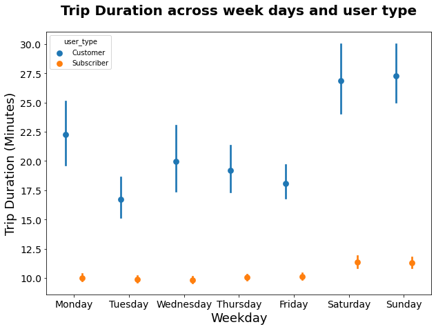

## (Visualization 2)

### Key Insight 2: Gender and User type influence on the Bike System Rentage focusing on Weekly Trips.

> - Male gender have highest number of bike usage weekly in both types of users.
> - Peak demand for bike rides is on Thursdays

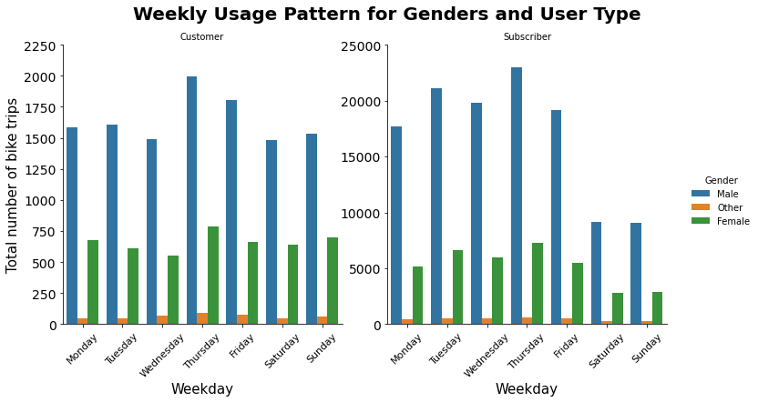

## (Visualization 3)

### Key Insight 3: Hourly usage patterns in the weekdays by both user types

> - Bike rides occur mostly in the morning and evening.
> - The heatmap gives a precise look at the trend for bike usage behaviour across both user categories.

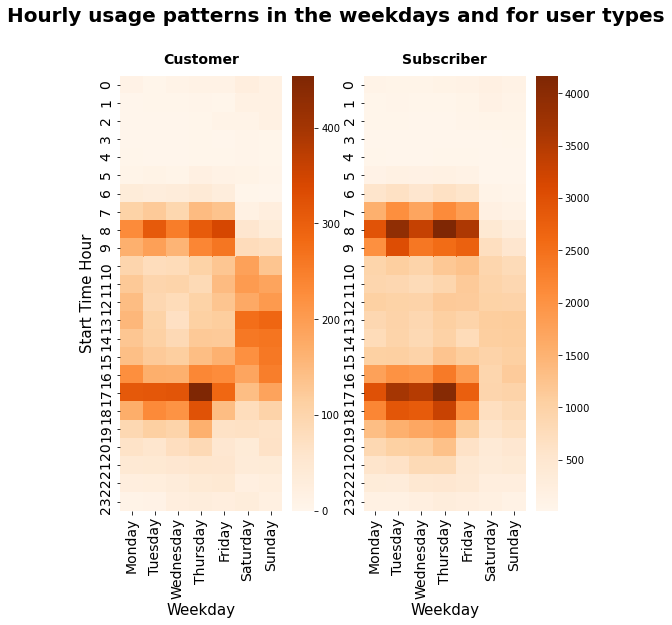

## (Visualization 4)

### Key Insight 4: Weekday popular amongst the bike user types

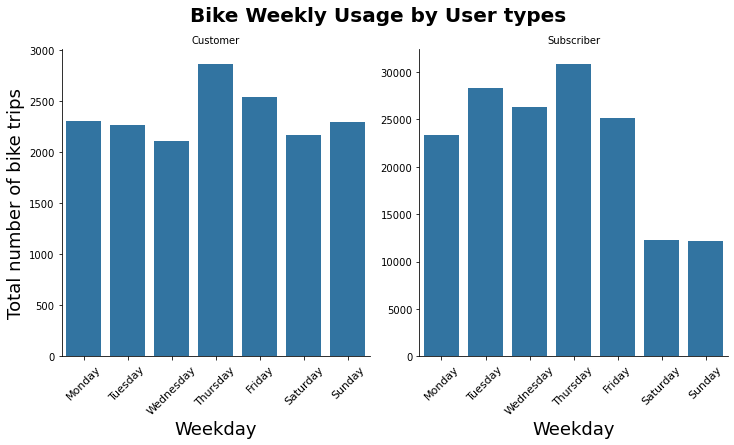